# ggcyto: Next generation visualization software for flow cytometry. Supplementary Information.

Phu T. Van, Mike Jiang, Greg Finak & Raphael Gottardo

March 28, 2018

# 1 Overview

This Supplementary Information document for the paper “ggcyto: Next generation visualization software for flow cytometry” shows how to use the BioConductor package `ggcyto` to visualize flow cytometry data and reproduces the plots from the original publication, together with code.

# 2 ggcyto supported data structures

`ggcyto` supports the core flow cytometry data structures in R/Bioconductor: `flowFrame` and `flowSet` (defined in the `flowCore` package) for ungated data, and `GatingSet` and `GatingHierarchy` (defined in the `flowWorkspace` package) for gated data.

This document use the “graft vs. host disease” (`GvHD`) data set from the `flowCore` package [on BioConductor](https://doi.org/doi:10.18129/B9.bioc.flowCore)), and part of the FlowCAP Lyoplate data that is in the `flowWorkspaceData` package, also [on BioConductor](https://doi.org/doi:10.18129/B9.bioc.flowWorkspaceData)).

# 3 Reproducing figures from the original manuscript.

The original manuscript shows three sets of plots created with `ggcyto`. We load the required data and use the code verbatim from the published figure to generate the associated plots.

```r
data(GvHD)
dataDir <- system.file("extdata",package="flowWorkspaceData")
gs <- load_gs(list.files(dataDir, pattern = "gs_bcell_auto",full = TRUE))
# Below we associate a transformation with the Lyoplate data GatingSet, which did not have one.
gs@transformation <- transformerList(colnames(gs)[-(1:2)], flowJo_biexp_trans())

# Choose a subset of samples.
fs <- GvHD[subset(pData(GvHD), Patient %in%5:7 & Visit %in% c(5:6))[["name"]]]

# Give meaningful visit and subject identifiers to the samples.
pd <- pData(fs)
pd$Visit <- paste("visit",pd$Visit)
pd$Patient <- paste("patient",pd$Patient)
pData(fs) <- pd
```

## 3.1 Figure 1 plots.

### 3.1.1 Autoplot API

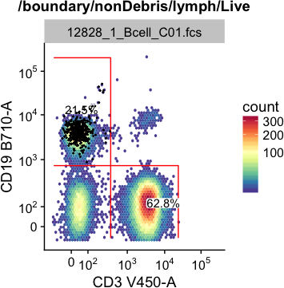

```r
autoplot(gs[1], c("CD3","CD19"), bins = 64) +
  geom_overlay("IgD+CD27+",size=0.25)
```

### 3.1.2 ggcyto API.

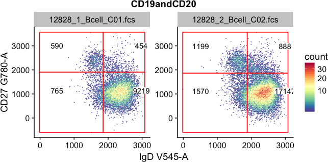

```r
ggcyto(gs[1:2], aes(x="IgD",y="CD27"),subset= c("CD19andCD20")) +
  geom_hex(bins=128) +
  geom_gate(c("IgD+CD27+","IgD+CD27-","IgD-CD27+","IgD-CD27-")) +
  geom_stats(type = "count")
```

### 3.1.3 transforming data.

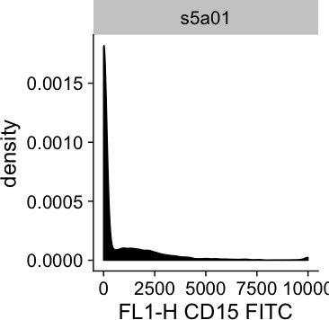

```r
#Use the first GvHD sample
fr <- GvHD[[1]]
p = autoplot(fr, "FL1-H") + theme_cowplot(font_size = 18)
print(p)
```

```r
#flowCore logicle scale
p + scale_x_logicle()
```

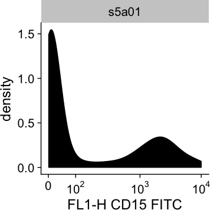

```r
# flowJo fasinh
p + scale_x_flowJo_fasinh()
```

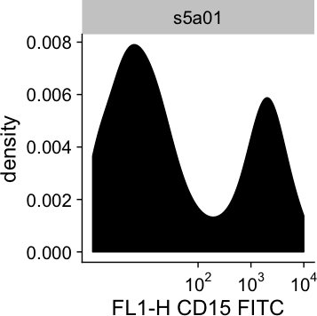

# 4 Additional ggcyto features.

The ggcyto package is built on `ggplot2` and uses the “grammar of graphics”. Below we demonstrate how its new features can be used to easily generate high quality plots of cytometry data.

## 4.1 Context-aware plots.

Following common `ggplot2` usage, `ggcyto` defines an `autoplot()` method. Calling `autoplot()` on a supported data structure automatically results in a default plot that is sensible for the data being displayed.

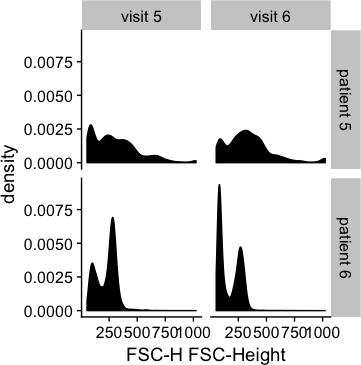

```r
autoplot(fs[1:4], "FSC-H") + facet_grid(Patient~Visit)
```

### 4.1.1 Changing `geom`s.

The plot can be easily modified to show a histogram by appending the appropriate `geom`.

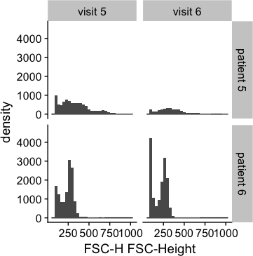

```r
autoplot(fs[1:4], "FSC-H") + facet_grid(Patient~Visit) + geom_histogram()
```

### 4.1.2 Using gated data.

Calling `autoplot` on a `GatingSet` or `GatingHierarchy` and supplying a **population name** results in a 1D or 2D density (depending on how the population is defined) using `geom_hex` or `geom_density`. Any gates in the GatingSet defined in those two dimensions are automatically overlaid on the plot:

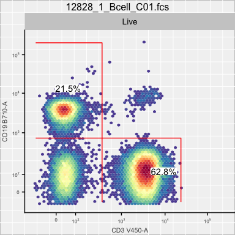

```r
autoplot(gs[[1]], c("CD3", "CD19"), bins = 64)
```

### 4.1.3 Visualizing back-gating.

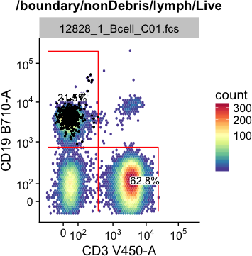

```r
autoplot(gs[1], c("CD3","CD19"), bins = 64) +
  geom_overlay("IgD+CD27+",size=0.5)
```

### 4.1.4 Changing the scales.

The `x` and `y` axis scales are transformed above but show the raw data values. These can be changed to show the transformed data values on a linear scale using the `axis_inverse_trans` argument to `autoplot`.

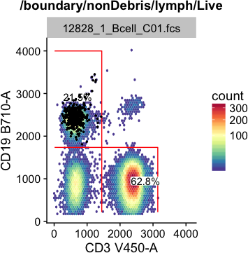

```r
autoplot(gs[1], c("CD3","CD19"), bins = 64, axis_inverse_trans = FALSE) +
  geom_overlay("IgD+CD27+",size=0.5)
```

### 4.1.5 Using the `ggcyto` interface.

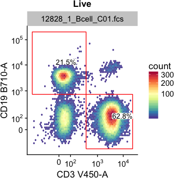

```r
ggcyto(gs[1], aes(x="CD3",y="CD19"),subset= "Live") +
  geom_hex(bins=64) +
  geom_gate(c("CD19","CD3")) +
  geom_stats(type = "percent") +
  axis_x_inverse_trans() +
  axis_y_inverse_trans()
```

## 4.2 A use case with the Lyoplate data.

We load the lyoplate data for the T cell panel. the data are available on [ImmuneSpace](http://www.immunespace.org).

```r
# load the Lyoplate gatingSet
gs2 <- rbind2(load_gslist("/Volumes/gottardo//mike_working/lyoplate_out/gated_data/auto/gslist-tcell/"))

gs2@transformation = transformerList(colnames(gs2)[-(1:2)], flowJo_biexp_trans())
```

The Lyoplate dataset for the T cell panel contains three biological samples. The samples were distributed across seven centers, an each center ran three technical replicates of each sample, as indicated in the metadata.

| name | Center | Sample | Replicate |
| --- | --- | --- | --- |
| 12828_1_Tcell_A01.fcs | NHLBI | 12828 | 1 |
| 12828_2_Tcell_A02.fcs | NHLBI | 12828 | 2 |
| 12828_3_Tcell_A03.fcs | NHLBI | 12828 | 3 |
| 1349_1_Tcell_A04.fcs | NHLBI | 1349 | 1 |
| 1349_2_Tcell_A05.fcs | NHLBI | 1349 | 2 |
| 1349_3_Tcell_A06.fcs | NHLBI | 1349 | 3 |
| 1369_1_Tcell_A07.fcs | NHLBI | 1369 | 1 |
| 1369_2_Tcell_A08.fcs | NHLBI | 1369 | 2 |
| 1369_3_Tcell_A09.fcs | NHLBI | 1369 | 3 |
| 12828_1_A1_A01.fcs | Yale | 12828 | 1 |
| 12828_2_A2_A02.fcs | Yale | 12828 | 2 |
| 12828_3_A3_A03.fcs | Yale | 12828 | 3 |
| 1349_1_A4_A04.fcs | Yale | 1349 | 1 |
| 1349_2_A5_A05.fcs | Yale | 1349 | 2 |
| 1349_3_A6_A06.fcs | Yale | 1349 | 3 |
| 1369_1_A7_A07.fcs | Yale | 1369 | 1 |
| 1369_2_A8_A08.fcs | Yale | 1369 | 2 |
| 1369_3_A9_A09.fcs | Yale | 1369 | 3 |
| TCELL 22013_12828_001.fcs | UCLA | 12828 | 1 |
| TCELL 22013_12828_002.fcs | UCLA | 12828 | 2 |
| TCELL 22013_12828_003.fcs | UCLA | 12828 | 3 |
| TCELL 22013_1349_001.fcs | UCLA | 1349 | 1 |
| TCELL 22013_1349_002.fcs | UCLA | 1349 | 2 |
| TCELL 22013_1349_003.fcs | UCLA | 1349 | 3 |
| TCELL 22013_1369_001.fcs | UCLA | 1369 | 1 |
| TCELL 22013_1369_002.fcs | UCLA | 1369 | 2 |
| TCELL 22013_1369_003.fcs | UCLA | 1369 | 3 |
| T_CELL_12828_001_P1.fcs | CIMR | 12828 | 2 |
| T_CELL_12828_002_P1.fcs | CIMR | 12828 | 3 |
| T_CELL_12828_P1.fcs | CIMR | 12828 | 1 |
| T_CELL_1349_001_P1.fcs | CIMR | 1349 | 2 |
| T_CELL_1349_002_P1.fcs | CIMR | 1349 | 3 |
| T_CELL_1349_P1.fcs | CIMR | 1349 | 1 |
| T_CELL_1369_001_P1.fcs | CIMR | 1369 | 2 |
| T_CELL_1369_002_P1.fcs | CIMR | 1369 | 3 |
| T_CELL_1369_P1.fcs | CIMR | 1369 | 1 |
| lot 12828_A1_A01.fcs | Miami | 12828 | 1 |
| lot 12828_A2_A02.fcs | Miami | 12828 | 2 |
| lot 12828_A3_A03.fcs | Miami | 12828 | 3 |
| lot 1349_A4_A04.fcs | Miami | 1349 | 1 |
| lot 1349_A5_A05.fcs | Miami | 1349 | 2 |
| lot 1349_A6_A06.fcs | Miami | 1349 | 3 |
| lot 1369_A7_A07.fcs | Miami | 1369 | 1 |
| lot 1369_A8_A08.fcs | Miami | 1369 | 2 |
| lot 1369_A9_A09.fcs | Miami | 1369 | 3 |
| 12828_1_T CELL.fcs | Baylor | 12828 | 1 |
| 12828_2_T CELL.fcs | Baylor | 12828 | 2 |
| 12828_3_T CELL.fcs | Baylor | 12828 | 3 |
| 1349_1_T CELL.fcs | Baylor | 1349 | 1 |
| 1349_2_T CELL.fcs | Baylor | 1349 | 2 |
| 1349_3_T CELL.fcs | Baylor | 1349 | 3 |
| 1369_1_T CELL.fcs | Baylor | 1369 | 1 |
| 1369_2_T CELL.fcs | Baylor | 1369 | 2 |
| 1369_3_T CELL.fcs | Baylor | 1369 | 3 |
| 1228-1_A1_A01.fcs | Stanford | 12828 | 1 |
| 1228-2_A2_A02.fcs | Stanford | 12828 | 2 |
| 1228-3_A3_A03.fcs | Stanford | 12828 | 3 |
| 1349-1_A4_A04.fcs | Stanford | 1349 | 1 |
| 1349-2_A5_A05.fcs | Stanford | 1349 | 2 |
| 1349-3_A6_A06.fcs | Stanford | 1349 | 3 |
| 1369-1_A7_A07.fcs | Stanford | 1369 | 1 |
| 1369-2_A8_A08.fcs | Stanford | 1369 | 2 |
| 1369-3_A9_A09.fcs | Stanford | 1369 | 3 |

The data was gated to identify CD4 and CD8 memory T cells:

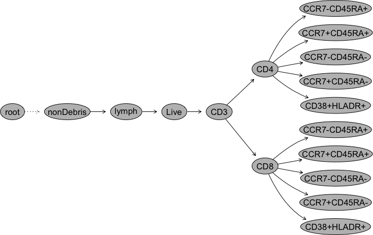

We can visualize variation across replicates and centers for sample #1349. The plot is built up using the `ggcyto()` API. Note we use `axis_x_inverse_trans` and `axis_y_inverse_trans` to transform the axes tick marks to a non-linear scale and display the raw data values.

The plot shows clearly that center-to-center variability is greater than variability across technical replicates.

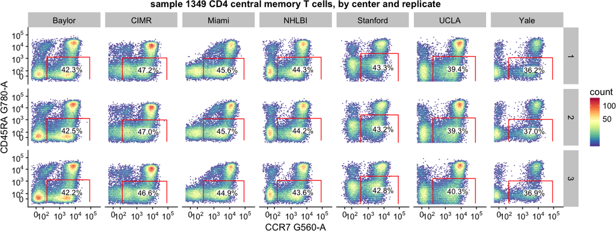

```r
p = ggcyto(subset(gs2, Sample=="1349")
        ,aes(x = CCR7,y=CD45RA)
        ,subset="CD4") +
        geom_hex(bins = 64) +
        geom_gate("CD4/CCR7+CD45RA-") +
        geom_stats() +
        facet_grid(Replicate ~ Center) +
        labs(title="sample 1349 CD4 central memory T cells, by center and replicate") +
        ggcyto_par_set(limits = "instrument") +
        axis_x_inverse_trans() +
        axis_y_inverse_trans()
p
```

### 4.2.1 Substituting data with the `%+%` method.

Here we use the `%+%` method to substitute the data in the plot. We’ll plot only a subset of the centers.. specifically Baylor and CIMR.

```r
p %+% subset(gs2,Center%in%c("Baylor","CIMR"))
```

[figure not shown]